# HW04 Part 1: Complete Chapter 3

### Section 3.7: Statistical transformations.

**Skip this section.** We may return to it later.

### Section 3.8 Position adjustments

#### Section 3.8 Questions

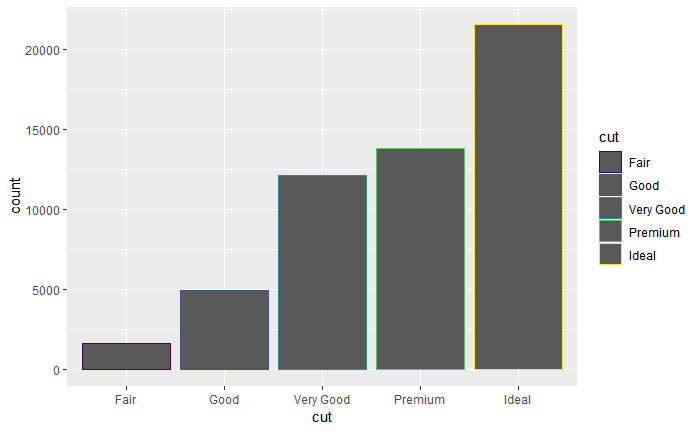

```r
ggplot(data = diamonds) +
  geom_bar(mapping = aes(x = cut, colour = cut))
```

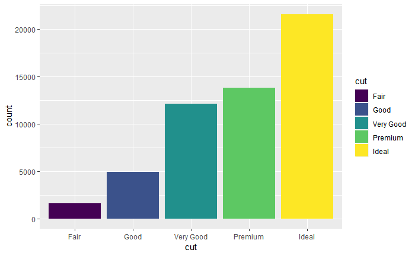

```r
ggplot(data = diamonds) +
  geom_bar(mapping = aes(x = cut, fill = cut))
```

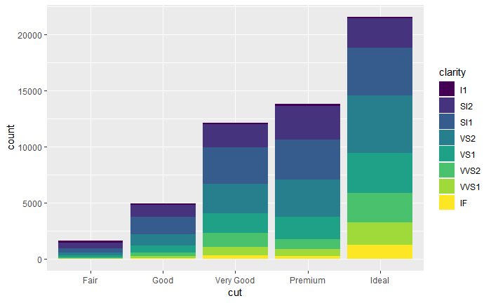

```r
ggplot(data = diamonds) +
  geom_bar(mapping = aes(x = cut, fill = clarity))
```

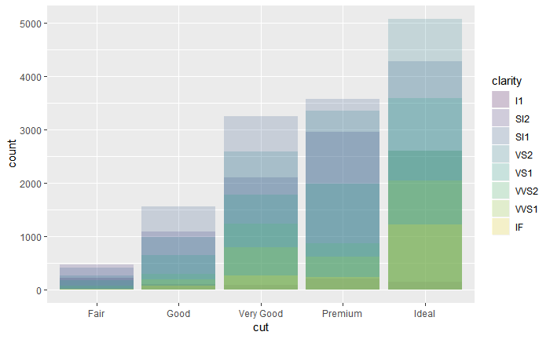

```r
ggplot(data = diamonds, mapping = aes(x = cut, fill = clarity)) +
  geom_bar(alpha = 1/5, position = "identity")
```

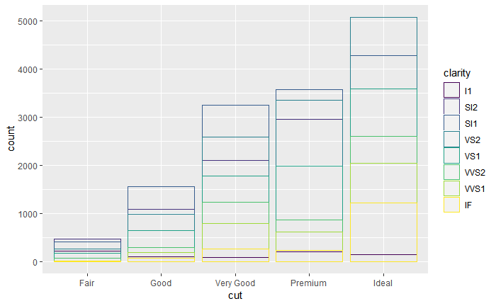

```r
ggplot(data = diamonds, mapping = aes(x = cut, colour = clarity)) +
  geom_bar(fill = NA, position = "identity")
```

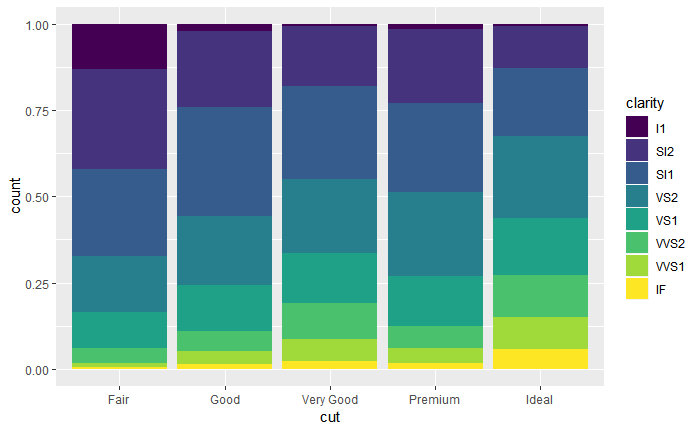

```r
ggplot(data = diamonds) +
  geom_bar(mapping = aes(x = cut, fill = clarity), position = "fill")
```

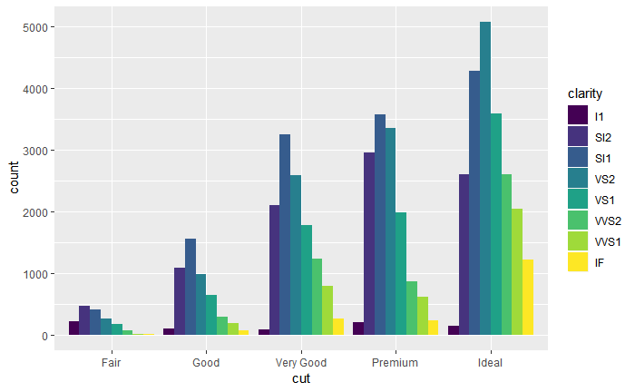

```r
ggplot(data = diamonds) +
  geom_bar(mapping = aes(x = cut, fill = clarity), position = "dodge")
```

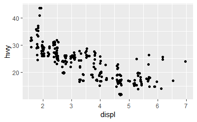

```r
ggplot(data = mpg) +
  geom_point(mapping = aes(x = displ, y = hwy), position = "jitter")
```

**1:** What is the problem with this plot? How could you improve it. *Hint:* Remember the size of the `mpg` data set from earlier in this exercise. Does the number of points seem correct? **Note:** Write the code to improve it.

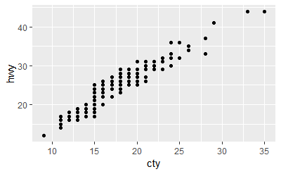

```r
ggplot(data = mpg, mapping = aes(x = cty, y = hwy)) +
  geom_point()
```

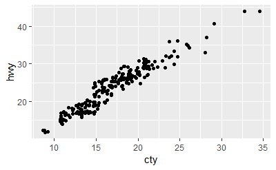

```r
ggplot(data = mpg, mapping = aes(x = cty, y = hwy)) +
  geom_jitter()
```

The problem was the points overlapped each other. The first graph was not showing all the points. I used the “geom_jitter” to fix this.

**2:** What parameters to `geom_jitter()` control the amount of jittering? Width and height parameters contol the amount of jittering in “geom_jitter()”.

**3:** Compare and contracts `geom_jitter()` with `geom_count()`.

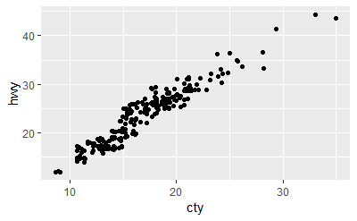

```r
ggplot(data = mpg, mapping = aes(x = cty, y = hwy)) +
  geom_jitter()
```

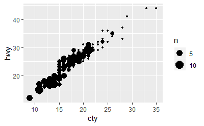

```r
ggplot(data = mpg, mapping = aes(x = cty, y = hwy)) +
  geom_count()
```

Jitter changes the position of the points while count changes the size of the points relative to how many points are in that area. They are both functions to help with overlapping of points.

**4:** What is the default position adjustement for `geom_boxplot()`? Create a visualization of the `mpg` dataset that demonstrates it.

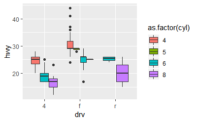

```r
ggplot(data = mpg, mapping = aes(x = drv, y = hwy, fill = as.factor(cyl))) +
  geom_boxplot()
```

The default position is dodge2.

### Section 3.9: Coordinate systems

**Note:** Read about and do only the code chunk associated with `coord_flip()`. `coord_flip()` is a great layer to use when you have categorical data with longish names as it makes the text easier to read.

### Section 3.10: The layered grammar of graphics

Just read this section as a contextual review of everything you just learned.